# Autism trees

16 September 2021

This lab looks at data collected to try to detect autism spectrum disorder (ASD) biochemically. (note: remove the non-biochemical variable).

We use trees to detect ASD.

## Tasks

1. Use `rpart()` to grow a tree that distinguishes the ASD and NEU groups, and give the confusion matrix and the proportion of people (from these two groups) correctly classified. Plot the tree (showing labels – make sure you set the margin in the plot call to make room for the labels).

```r
raw_autism <- read_csv("S1Dataset.csv") # read in the data
spec(raw_autism) # check data
# fix character to numeric
vnames <- read_csv("S1Dataset.csv",n_max=0)
raw_autism <- read_csv("S1Dataset.csv",skip=2) # Need to ignore 2nd row as it contains units only.
names(raw_autism) <- names(vnames)
spec(raw_autism) # check again
```

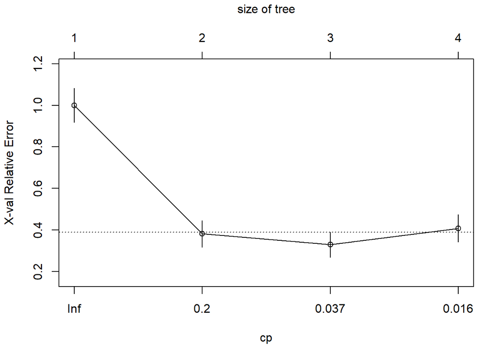

```r
autism <- raw_autism[, -26] # skip the last column as the last column is not a biochemical variable.
autism_AN <- autism %>% filter(Group %in% c("ASD", "NEU")) # remove the rows of SIB groups.

# a tree
library(rpart)
tree_AN <- autism_AN %>% rpart(Group~., data =.) # grow a tree
plotcp(tree_AN) # plot the output of the cross-validation
```

Overfitting not a problem here, let’s just stick with unpruned tree.

```r
#printcp(tree_AN) # print the output of the cross-validation
predict1 <-  predict(tree_AN, type = "class") # Sufficient to get fitted values out
confMatrix1 <- with(autism_AN, table(actual=Group, predicted=predict1)) # confusion matrix

# the proportion of people (from these two groups) correctly classified
sum(diag(confMatrix1)) / nrow(autism_AN)
```

```
## [1] 0.9113924
```

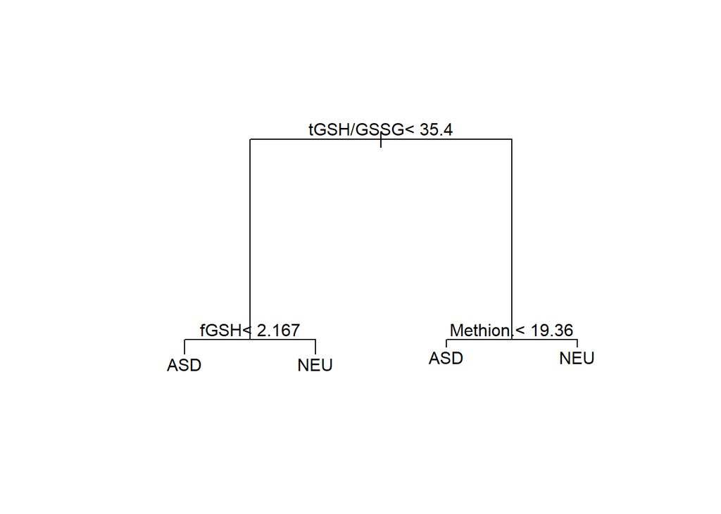

```r
plot(tree_AN, margin=0.2) # plot the tree
text(tree_AN)
```

2. The dataset makes the classifier look good, because the number of ASD and neurotypical participants are equal. In reality, ASD affects about 1.5% of people. Run `rpart()` with the prior argument (see the help page), to build a tree based on population prior probabilities of 0.015 and 0.985. Report the confusion matrix and the proportion of ASD and NEU groups correctly classified. Plot the tree.

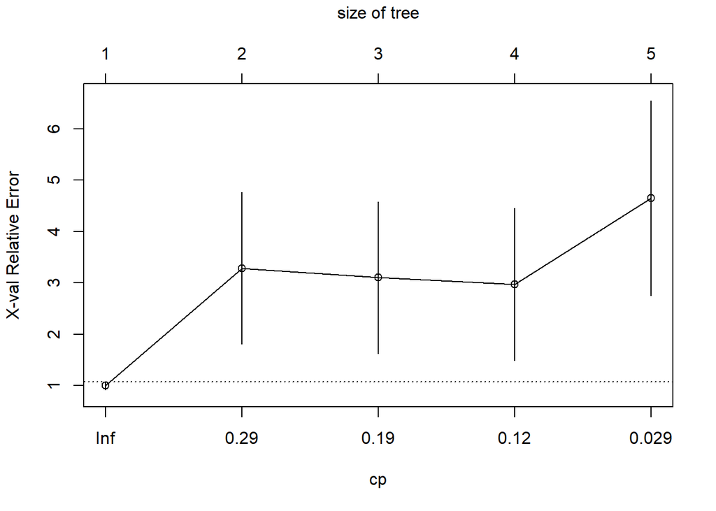

```r
# a tree
tree_AN_2 <- autism_AN %>% rpart(Group~., parms = list(prior = c(.015, .985)), data =.) # grow a tree

plotcp(tree_AN_2) # plot the output of the cross-validation
```

```r
predict2 = predict(prune(tree_AN_2, cp = 1), type = "class") # Sufficient to get fitted values out

confMatrix2 <- with(autism_AN, table(actual=Group, predicted=predict2)) # confusion matrix
sum(diag(confMatrix2)) / nrow(autism_AN) # proportion correct
```

```
## [1] 0.4810127
```

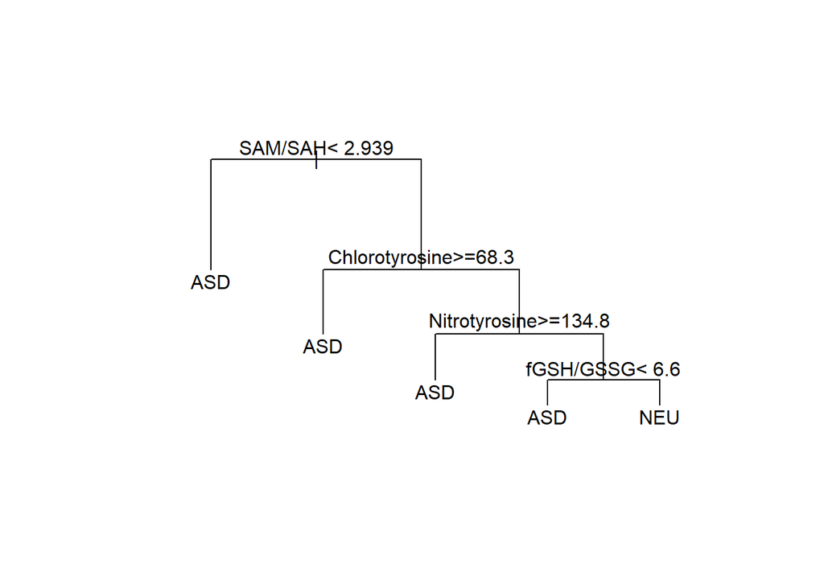

```r
# no tree to plot here, just a root...
# just plot the whole tree
plot(tree_AN_2, margin=0.2) # plot the tree
text(tree_AN_2)
```

```r
#printcp(tree_AN_2) # print the output of the cross-validation
```

3. Suppose that false negative classifications (missing ASD) are thought to be more important than false positive (suspecting ASD). Run `rpart()` with the `prior` argument as in the previous question and also with the `loss` argument saying that false negatives are 10 times as bad as false positives. Report the confusion matrix and the proportion of ASD and NEU groups correctly classified. Plot the tree. Did you get the result you expected?

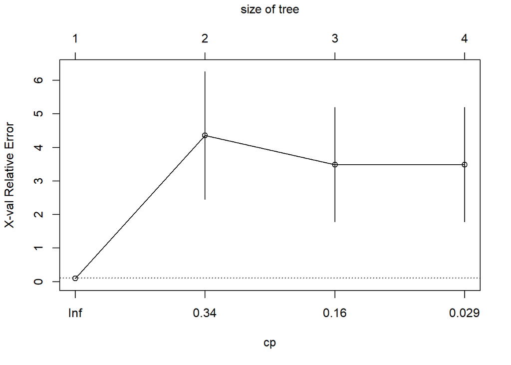

```r
lossmatrix <- matrix(c(0,10,1,0), byrow = TRUE, nrow = 2)
# a tree
tree_AN_3 <- autism_AN %>% rpart(Group~., parms = list(loss = lossmatrix, prior = c(.015, .985)), data =.) # grow a tree
plotcp(tree_AN_3) # plot the output of the cross-validation
```

This is not the result we expected - the best tree is not worth plotting as it is just a stump and we know the classification is not good. It is possible the greedy nature of the algorithm is causing problems here.

Lets see if increasing the penalty to 100 improves things.

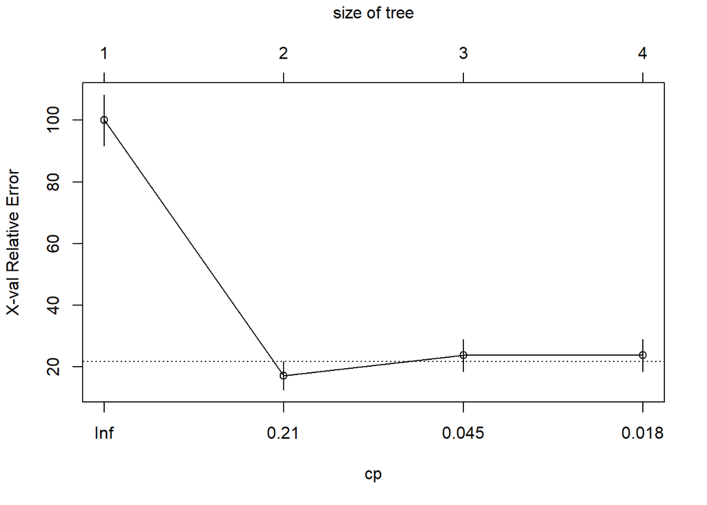

```r
lossmatrix <- matrix(c(0,100,1,0), byrow = TRUE, nrow = 2)
# a tree
tree_AN_3 <- autism_AN %>% rpart(Group~., parms = list(loss = lossmatrix, prior = c(.015, .985)), data =.) # grow a tree
plotcp(tree_AN_3) # plot the output of the cross-validation
```

That is better. Looks like the best model has two nodes, so prune it back to there:

```r
tree_AN_3 = prune(tree_AN_3, cp = .2)

predict3 = predict(tree_AN_3, type = "class") # Sufficient to get fitted values out

confMatrix3 = table(Actual = autism_AN$Group, Predicted = predict3)
correct3 = (confMatrix3[1,1] + confMatrix3[2,2]) / nrow(autism_AN)
confMatrix3
```

```
##       Predicted
## Actual ASD NEU
##    ASD  73   9
##    NEU  11  65
```

```r
# proportion correct
sum(diag(confMatrix3)) / nrow(autism_AN)
```

```
## [1] 0.8734177
```

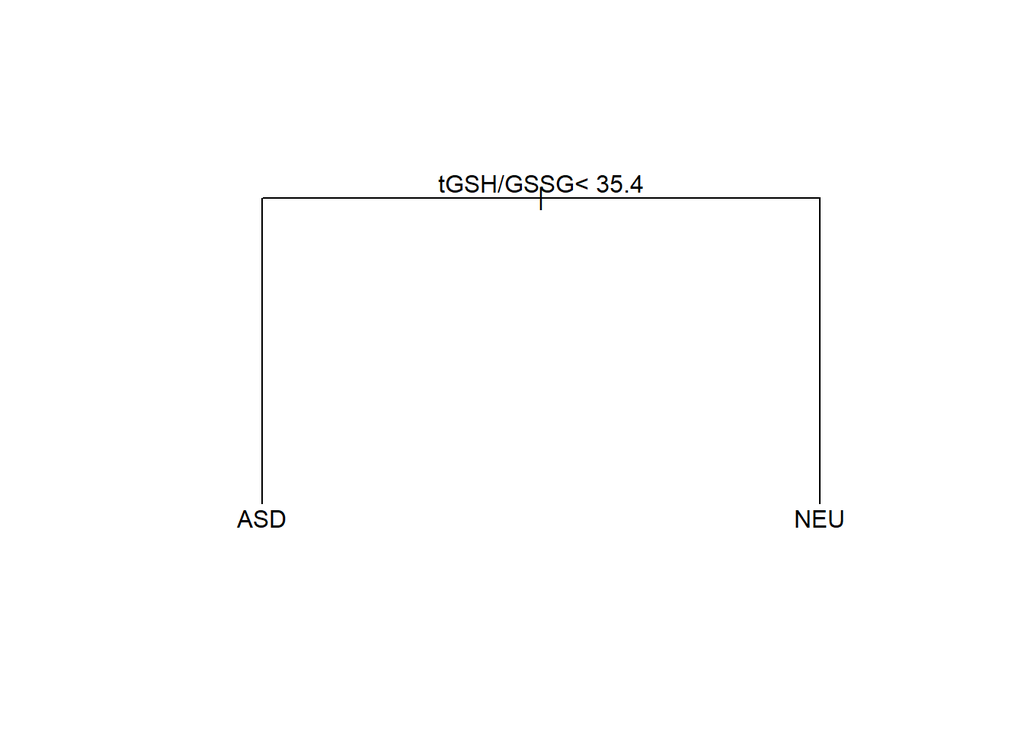

```r
plot(tree_AN_3, margin=0.2) # plot the tree
text(tree_AN_3)
```

```r
#printcp(tree_AN_3) # print the output of the cross-validation
```

4. Use this final tree to predict for the SIB group (all of whom are actually neurotypical). What proportion are correctly classified?

```r
SIB <- autism %>% filter(Group == "SIB")
predict4 <- predict(tree_AN_3, SIB, type = "class")
(confMatrix4 <- table(predict4))
```

```
## predict4
## ASD NEU
##  13  34
```

```r
# proportions
confMatrix4/sum(confMatrix4)
```

```
## predict4
##       ASD       NEU
## 0.2765957 0.7234043
```

So only about 72% correctly classified.